# anz task 1

```python
import pandas as pd
import pylab as pl
import numpy as np
import scipy.optimize as opt
from sklearn import preprocessing
%matplotlib inline
import matplotlib.pyplot as plt
import seaborn as sns
```

```python
my_data = pd.read_excel('C:/Users/Guoli/Documents/Data Science Material/Projects/ANZ/ANZ synthesised transaction dataset.xlsx')
```

```python
my_data.head()
```

|  | status | card_present_flag | bpay_biller_code | account | currency | long_lat | txn_description | merchant_id | merchant_code | first_name | ... | age | merchant_suburb | merchant_state | extraction | amount | transaction_id | country | customer_id | merchant_long_lat | movement |
| --- | --- | --- | --- | --- | --- | --- | --- | --- | --- | --- | --- | --- | --- | --- | --- | --- | --- | --- | --- | --- | --- |
| 0 | authorized | 1.0 | NaN | ACC-1598451071 | AUD | 153.41 -27.95 | POS | 81c48296-73be-44a7-befa-d053f48ce7cd | NaN | Diana | ... | 26 | Ashmore | QLD | 2018-08-01T01:01:15.000+0000 | 16.25 | a623070bfead4541a6b0fff8a09e706c | Australia | CUS-2487424745 | 153.38 -27.99 | debit |
| 1 | authorized | 0.0 | NaN | ACC-1598451071 | AUD | 153.41 -27.95 | SALES-POS | 830a451c-316e-4a6a-bf25-e37caedca49e | NaN | Diana | ... | 26 | Sydney | NSW | 2018-08-01T01:13:45.000+0000 | 14.19 | 13270a2a902145da9db4c951e04b51b9 | Australia | CUS-2487424745 | 151.21 -33.87 | debit |
| 2 | authorized | 1.0 | NaN | ACC-1222300524 | AUD | 151.23 -33.94 | POS | 835c231d-8cdf-4e96-859d-e9d571760cf0 | NaN | Michael | ... | 38 | Sydney | NSW | 2018-08-01T01:26:15.000+0000 | 6.42 | feb79e7ecd7048a5a36ec889d1a94270 | Australia | CUS-2142601169 | 151.21 -33.87 | debit |
| 3 | authorized | 1.0 | NaN | ACC-1037050564 | AUD | 153.10 -27.66 | SALES-POS | 48514682-c78a-4a88-b0da-2d6302e64673 | NaN | Rhonda | ... | 40 | Buderim | QLD | 2018-08-01T01:38:45.000+0000 | 40.90 | 2698170da3704fd981b15e64a006079e | Australia | CUS-1614226872 | 153.05 -26.68 | debit |
| 4 | authorized | 1.0 | NaN | ACC-1598451071 | AUD | 153.41 -27.95 | SALES-POS | b4e02c10-0852-4273-b8fd-7b3395e32eb0 | NaN | Diana | ... | 26 | Mermaid Beach | QLD | 2018-08-01T01:51:15.000+0000 | 3.25 | 329adf79878c4cf0aeb4188b4691c266 | Australia | CUS-2487424745 | 153.44 -28.06 | debit |

5 rows × 23 columns

```python
my_data.shape
```

```
(12043, 23)
```

```python
my_data.info()
```

```
<class 'pandas.core.frame.DataFrame'>
RangeIndex: 12043 entries, 0 to 12042
Data columns (total 23 columns):
 #   Column             Non-Null Count  Dtype
---  ------             --------------  -----
 0   status             12043 non-null  object
 1   card_present_flag  7717 non-null   float64
 2   bpay_biller_code   885 non-null    object
 3   account            12043 non-null  object
 4   currency           12043 non-null  object
 5   long_lat           12043 non-null  object
 6   txn_description    12043 non-null  object
 7   merchant_id        7717 non-null   object
 8   merchant_code      883 non-null    float64
 9   first_name         12043 non-null  object
 10  balance            12043 non-null  float64
 11  date               12043 non-null  datetime64[ns]
 12  gender             12043 non-null  object
 13  age                12043 non-null  int64
 14  merchant_suburb    7717 non-null   object
 15  merchant_state     7717 non-null   object
 16  extraction         12043 non-null  object
 17  amount             12043 non-null  float64
 18  transaction_id     12043 non-null  object
 19  country            12043 non-null  object
 20  customer_id        12043 non-null  object
 21  merchant_long_lat  7717 non-null   object
 22  movement           12043 non-null  object
dtypes: datetime64[ns](1), float64(4), int64(1), object(17)
memory usage: 2.1+ MB
```

```python
null_values = my_data.isnull().sum()
null_values
```

```
status                   0
card_present_flag     4326
bpay_biller_code     11158
account                  0
currency                 0
long_lat                 0
txn_description          0
merchant_id           4326
merchant_code        11160
first_name               0
balance                  0
date                     0
gender                   0
age                      0
merchant_suburb       4326
merchant_state        4326
extraction               0
amount                   0
transaction_id           0
country                  0
customer_id              0
merchant_long_lat     4326
movement                 0
dtype: int64
```

```python
null_values = null_values[null_values>0]
null_values_percentage = round(null_values/len(my_data), 4) * 100
pd.DataFrame({'Number of null': null_values, 'percentage': null_values_percentage}).sort_values(by = 'percentage', ascending = False)
```

|  | Number of null | percentage |
| --- | --- | --- |
| merchant_code | 11160 | 92.67 |
| bpay_biller_code | 11158 | 92.65 |
| card_present_flag | 4326 | 35.92 |
| merchant_id | 4326 | 35.92 |
| merchant_suburb | 4326 | 35.92 |
| merchant_state | 4326 | 35.92 |
| merchant_long_lat | 4326 | 35.92 |

```python
my_data.columns
```

```
Index(['status', 'card_present_flag', 'bpay_biller_code', 'account',
       'currency', 'long_lat', 'txn_description', 'merchant_id',
       'merchant_code', 'first_name', 'balance', 'date', 'gender', 'age',
       'merchant_suburb', 'merchant_state', 'extraction', 'amount',
       'transaction_id', 'country', 'customer_id', 'merchant_long_lat',
       'movement'],
      dtype='object')
```

## Exploratory Data Analysis

We are going to drop the following account information as they are not much helpful here.

bpay_biller_code, account, merchant_id, merchant_code, first_name, transaction_id, customer_id.

```python
data = my_data.drop(['bpay_biller_code', 'account', 'merchant_id', 'merchant_code', 'first_name', 'transaction_id', 'customer_id'], axis = 1)
data.head()
```

|  | status | card_present_flag | currency | long_lat | txn_description | balance | date | gender | age | merchant_suburb | merchant_state | extraction | amount | country | merchant_long_lat | movement |
| --- | --- | --- | --- | --- | --- | --- | --- | --- | --- | --- | --- | --- | --- | --- | --- | --- |
| 0 | authorized | 1.0 | AUD | 153.41 -27.95 | POS | 35.39 | 2018-08-01 | F | 26 | Ashmore | QLD | 2018-08-01T01:01:15.000+0000 | 16.25 | Australia | 153.38 -27.99 | debit |
| 1 | authorized | 0.0 | AUD | 153.41 -27.95 | SALES-POS | 21.20 | 2018-08-01 | F | 26 | Sydney | NSW | 2018-08-01T01:13:45.000+0000 | 14.19 | Australia | 151.21 -33.87 | debit |
| 2 | authorized | 1.0 | AUD | 151.23 -33.94 | POS | 5.71 | 2018-08-01 | M | 38 | Sydney | NSW | 2018-08-01T01:26:15.000+0000 | 6.42 | Australia | 151.21 -33.87 | debit |
| 3 | authorized | 1.0 | AUD | 153.10 -27.66 | SALES-POS | 2117.22 | 2018-08-01 | F | 40 | Buderim | QLD | 2018-08-01T01:38:45.000+0000 | 40.90 | Australia | 153.05 -26.68 | debit |
| 4 | authorized | 1.0 | AUD | 153.41 -27.95 | SALES-POS | 17.95 | 2018-08-01 | F | 26 | Mermaid Beach | QLD | 2018-08-01T01:51:15.000+0000 | 3.25 | Australia | 153.44 -28.06 | debit |

```python
data['status'].value_counts(dropna = False)
```

```
authorized    7717
posted        4326
Name: status, dtype: int64
```

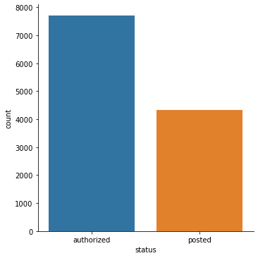

```python
sns.factorplot('status', data = data, kind = 'count')
```

```python
data['card_present_flag'].value_counts(dropna = False)
```

```
1.0    6194
NaN    4326
0.0    1523
Name: card_present_flag, dtype: int64
```

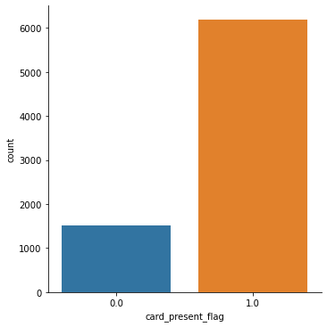

```python
sns.factorplot(x = 'card_present_flag', data = data, kind = 'count')
```

```python
data['currency'].value_counts(dropna = False)
```

```
AUD    12043
Name: currency, dtype: int64
```

we can drop the currency column since it doesn't provide much information.

```python
data = data.drop(['currency'], axis = 1)
```

```python
data['long_lat'].value_counts(dropna = False)
```

```
153.41 -27.95    578
151.23 -33.94    303
116.06 -32.00    292
145.45 -37.74    260
153.10 -27.66    259
                ...
149.03 -35.25     40
149.19 -21.15     37
145.09 -37.82     34
130.98 -12.49     31
147.61 -37.82     25
Name: long_lat, Length: 100, dtype: int64
```

```python
data['long_lat'].nunique()
```

```
100
```

```python
data['txn_description'].value_counts(dropna = False)
```

```
SALES-POS     3934
POS           3783
PAYMENT       2600
PAY/SALARY     883
INTER BANK     742
PHONE BANK     101
Name: txn_description, dtype: int64
```

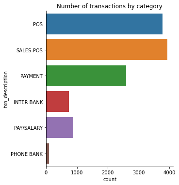

```python
plt.figure(figsize = (15, 5))
sns.factorplot(y = 'txn_description', data = data, kind = 'count')
plt.title("Number of transactions by category")
```

Most transactions are made by SALES-POS and the POS.

```python
a = pd.DataFrame(data.groupby('txn_description')['amount'].sum())
a
```

| txn_description | amount |
| --- | --- |
| INTER BANK | 64331.00 |
| PAY/SALARY | 1676576.85 |
| PAYMENT | 201794.00 |
| PHONE BANK | 10716.00 |
| POS | 152861.24 |
| SALES-POS | 157005.11 |

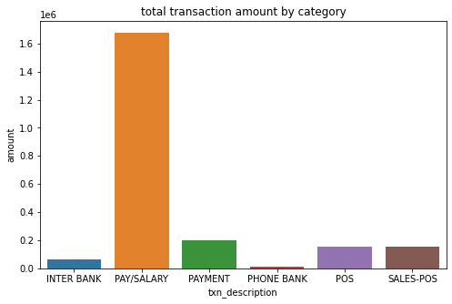

```python
plt.figure(figsize = (8, 5))
sns.barplot(x = a.index, y = "amount", data = a)
plt.title("total transaction amount by category")
```

### Purchases amount

```python
d = pd.DataFrame(data[['txn_description', 'amount']].loc[(t.txn_description == 'POS') | (t.txn_description == 'SALES-POS')])
d.head()
```

|  | txn_description | amount |
| --- | --- | --- |
| 0 | POS | 16.25 |
| 1 | SALES-POS | 14.19 |
| 2 | POS | 6.42 |
| 3 | SALES-POS | 40.90 |
| 4 | SALES-POS | 3.25 |

```python
purchases_amount = pd.DataFrame(d.groupby(['txn_description'])['amount'].sum())
purchases_amount
```

| txn_description | amount |
| --- | --- |
| POS | 152861.24 |
| SALES-POS | 157005.11 |

```python
purchases_amount.describe()
```

|  | amount |
| --- | --- |
| count | 2.000000 |
| mean | 154933.175000 |
| std | 2930.158577 |
| min | 152861.240000 |
| 25% | 153897.207500 |
| 50% | 154933.175000 |
| 75% | 155969.142500 |
| max | 157005.110000 |

Pay/salary has the largest total transaction amount.

```python
data['gender'].value_counts(dropna = False)
```

```
M    6285
F    5758
Name: gender, dtype: int64
```

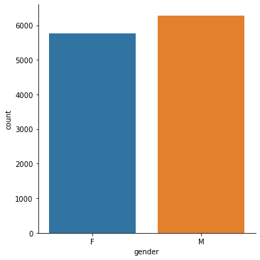

```python
sns.factorplot('gender', data = data, kind = 'count')
```

```python
b = data[['gender', 'amount']]
b.groupby('gender', as_index = False).mean()
```

|  | gender | amount |
| --- | --- | --- |
| 0 | F | 168.517303 |
| 1 | M | 205.721809 |

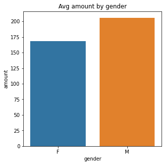

```python
plt.figure(figsize = (5, 5))
sns.barplot(x = 'gender', y = 'amount', data = b.groupby('gender', as_index = False).mean() )
plt.title('Avg amount by gender')
```

Male has higher transaction amount than female.

```python
data['merchant_suburb'].value_counts(dropna = False)
```

```
NaN                4326
Melbourne           255
Sydney              233
Southport            82
Brisbane City        79
                   ...
Kirribilli            1
Oatlands              1
Pendle Hill           1
Weston Creek          1
Caulfield South       1
Name: merchant_suburb, Length: 1610, dtype: int64
```

```python
data['merchant_state'].value_counts(dropna = False)
```

```
NaN    4326
NSW    2169
VIC    2131
QLD    1556
WA     1100
SA      415
NT      205
ACT      73
TAS      68
Name: merchant_state, dtype: int64
```

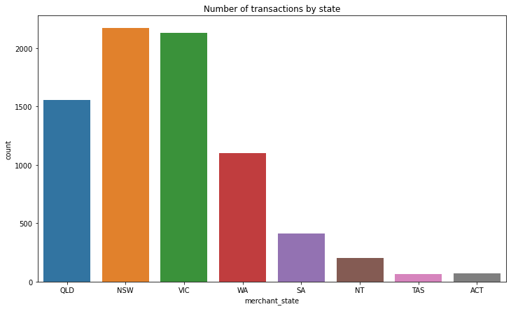

```python
plt.figure(figsize = (12, 7))
sns.countplot(data.merchant_state)
plt.title("Number of transactions by state")
```

NSW and VIC are the two states that had the most number of transactions

```python
c = data[['merchant_state', 'amount']].groupby(by = 'merchant_state', as_index = False).mean().sort_values(by = 'amount', ascending = False)
c = c.rename(columns = {'amount': 'avg_amount'})
c
```

|  | merchant_state | avg_amount |
| --- | --- | --- |
| 0 | ACT | 66.803836 |
| 1 | NSW | 47.036316 |
| 2 | NT | 44.726293 |
| 6 | VIC | 41.099953 |
| 4 | SA | 40.425470 |
| 3 | QLD | 34.372397 |
| 7 | WA | 30.901873 |
| 5 | TAS | 28.866618 |

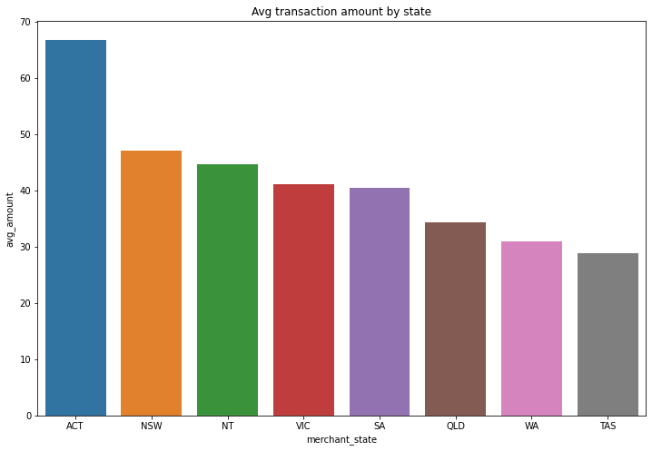

```python
plt.figure(figsize = (12,8))
sns.barplot(x = 'merchant_state', y = 'avg_amount', data = c)
plt.title('Avg transaction amount by state')
```

state ACT had the higest transaction amount.

```python
data['country'].value_counts(dropna = False)
```

```
Australia    12043
Name: country, dtype: int64
```

We can also drop the country column since it doesn't provide much information.

```python
data = data.drop(['country'], axis = 1)
```

```python
data[['date', 'extraction']].head(3)
```

|  | date | extraction |
| --- | --- | --- |
| 0 | 2018-08-01 | 2018-08-01T01:01:15.000+0000 |
| 1 | 2018-08-01 | 2018-08-01T01:13:45.000+0000 |
| 2 | 2018-08-01 | 2018-08-01T01:26:15.000+0000 |

```python
data['merchant_long_lat'].head()
```

```
0    153.38 -27.99
1    151.21 -33.87
2    151.21 -33.87
3    153.05 -26.68
4    153.44 -28.06
Name: merchant_long_lat, dtype: object
```

```python
data['movement'].value_counts(dropna = False)
```

```
debit     11160
credit      883
Name: movement, dtype: int64
```

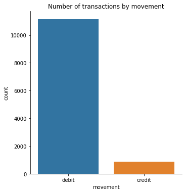

```python
sns.factorplot('movement', data = data, kind = 'count')
plt.title("Number of transactions by movement")
```

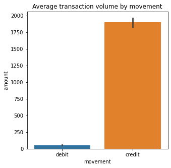

```python
plt.figure(figsize = (5, 5))
sns.barplot(x = "movement", y = "amount", data = data)
plt.title("Average transaction volume by movement")
```

Now let's look at the numerical variables

```python
data.head(3)
```

|  | status | card_present_flag | long_lat | txn_description | balance | date | gender | age | merchant_suburb | merchant_state | extraction | amount | merchant_long_lat | movement |
| --- | --- | --- | --- | --- | --- | --- | --- | --- | --- | --- | --- | --- | --- | --- |
| 0 | authorized | 1.0 | 153.41 -27.95 | POS | 35.39 | 2018-08-01 | F | 26 | Ashmore | QLD | 2018-08-01T01:01:15.000+0000 | 16.25 | 153.38 -27.99 | debit |
| 1 | authorized | 0.0 | 153.41 -27.95 | SALES-POS | 21.20 | 2018-08-01 | F | 26 | Sydney | NSW | 2018-08-01T01:13:45.000+0000 | 14.19 | 151.21 -33.87 | debit |
| 2 | authorized | 1.0 | 151.23 -33.94 | POS | 5.71 | 2018-08-01 | M | 38 | Sydney | NSW | 2018-08-01T01:26:15.000+0000 | 6.42 | 151.21 -33.87 | debit |

```python
data.balance.head(10)
```

```
0      35.39
1      21.20
2       5.71
3    2117.22
4      17.95
5    1705.43
6    1248.36
7    1232.75
8     213.16
9     466.58
Name: balance, dtype: float64
```

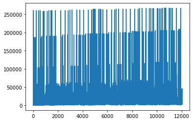

```python
data.balance.plot()
```

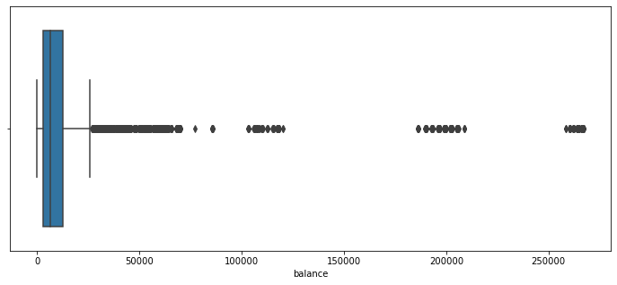

```python
plt.figure(figsize = (12, 5))
sns.boxplot(data.balance)
```

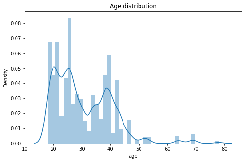

```python
plt.figure(figsize = (8, 5))
sns.distplot(data.age)
plt.title("Age distribution")
```

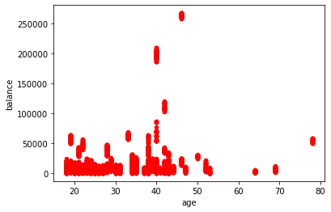

```python
plt.figure(figsize = (15, 8))
data.plot(kind = 'scatter', x = 'age', y = 'balance', color = 'red')
```

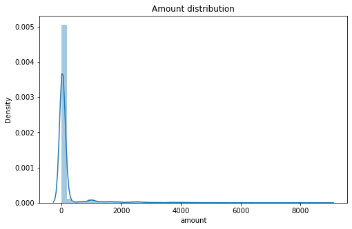

```python
plt.figure(figsize = (8, 5))
sns.distplot(data.amount)
plt.title("Amount distribution")
```

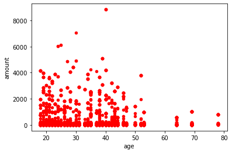

```python
plt.figure(figsize = (15, 8))
data.plot(kind = 'scatter', x = 'age', y = 'amount', color = 'red')
```

```python
daily_amount = pd.DataFrame(data.groupby('date')['amount'].mean())
daily_amount.head()
```

| date | amount |
| --- | --- |
| 2018-08-01 | 218.014161 |
| 2018-08-02 | 143.331053 |
| 2018-08-03 | 242.653376 |
| 2018-08-04 | 53.356356 |
| 2018-08-05 | 44.265000 |

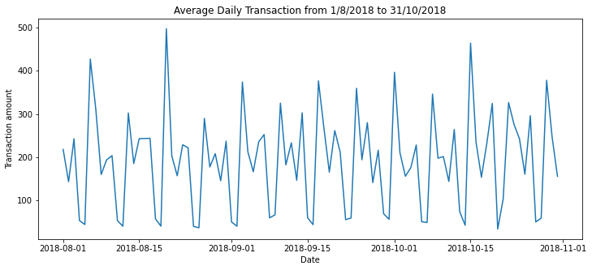

```python
fig, ax = plt.subplots(figsize = (12, 5))
ax.plot(daily_amount.index, daily_amount.amount)
plt.title("Average Daily Transaction from 1/8/2018 to 31/10/2018")
plt.xlabel("Date")
plt.ylabel("Transaction amount")
```

There appears to be a cyclical pattern in transaction volume over the 3 month period. My hypothesis for this occurence is:

Salaries are paid out only on certain days of the week

People tend to spend more during the weekends (shopping, going out with friends etc)

```python
data['date'] = pd.to_datetime(data['date'])
data['Year_Month'] = [x.year * 100 + x.month  for x in data['date']]
data.head()
```

|  | status | card_present_flag | long_lat | txn_description | balance | date | gender | age | merchant_suburb | merchant_state | extraction | amount | merchant_long_lat | movement | Year_Month |
| --- | --- | --- | --- | --- | --- | --- | --- | --- | --- | --- | --- | --- | --- | --- | --- |
| 0 | authorized | 1.0 | 153.41 -27.95 | POS | 35.39 | 2018-08-01 | F | 26 | Ashmore | QLD | 2018-08-01T01:01:15.000+0000 | 16.25 | 153.38 -27.99 | debit | 201808 |
| 1 | authorized | 0.0 | 153.41 -27.95 | SALES-POS | 21.20 | 2018-08-01 | F | 26 | Sydney | NSW | 2018-08-01T01:13:45.000+0000 | 14.19 | 151.21 -33.87 | debit | 201808 |
| 2 | authorized | 1.0 | 151.23 -33.94 | POS | 5.71 | 2018-08-01 | M | 38 | Sydney | NSW | 2018-08-01T01:26:15.000+0000 | 6.42 | 151.21 -33.87 | debit | 201808 |
| 3 | authorized | 1.0 | 153.10 -27.66 | SALES-POS | 2117.22 | 2018-08-01 | F | 40 | Buderim | QLD | 2018-08-01T01:38:45.000+0000 | 40.90 | 153.05 -26.68 | debit | 201808 |
| 4 | authorized | 1.0 | 153.41 -27.95 | SALES-POS | 17.95 | 2018-08-01 | F | 26 | Mermaid Beach | QLD | 2018-08-01T01:51:15.000+0000 | 3.25 | 153.44 -28.06 | debit | 201808 |

```python
monthly_amount = pd.DataFrame(data.groupby('Year_Month')['amount'].mean())
monthly_amount
```

| Year_Month | amount |
| --- | --- |
| 201808 | 185.121867 |
| 201809 | 182.045903 |
| 201810 | 196.427323 |

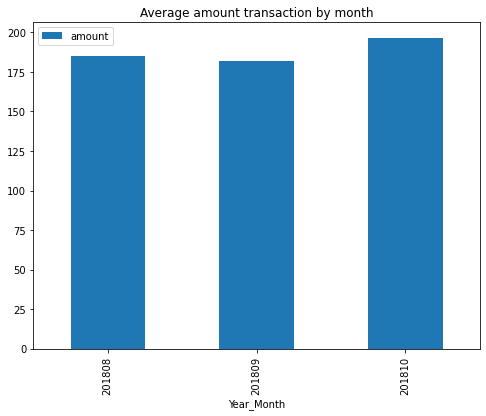

```python
#sns.barplot(x = 'Year_Month', y = 'amount', data = monthly_amount)
monthly_amount.plot(kind = 'bar', figsize = (8, 6))
plt.title('Average amount transaction by month')
```

Salaries are paid out only on certain days of the week

People tend to spend more during the weekends (shopping, going out with friends etc)

```python
data.isnull().sum()
```

```
status                  0
card_present_flag    4326
long_lat                0
txn_description         0
balance                 0
date                    0
gender                  0
age                     0
merchant_suburb      4326
merchant_state       4326
extraction              0
amount                  0
merchant_long_lat    4326
movement                0
dtype: int64
```

```python
nonSale = data.loc[(data.txn_description != "SALES-POS") | (data.txn_description != "POS"), :]
nonSale.isnull().sum().sort_values(ascending = False)
```

```
card_present_flag    4326
merchant_suburb      4326
merchant_state       4326
merchant_long_lat    4326
status                  0
long_lat                0
txn_description         0
balance                 0
date                    0
gender                  0
age                     0
extraction              0
amount                  0
movement                0
dtype: int64
```

Missing values in the above columns all originate from non-purchases transactions.

```python
cols = ['card_present_flag', 'merchant_state', 'merchant_suburb', 'merchant_long_lat']
for col in cols:
    data[col].fillna("n/a", inplace = True)
```

```python
data.isnull().sum()
```

```
status               0
card_present_flag    0
long_lat             0
txn_description      0
balance              0
date                 0
gender               0
age                  0
merchant_suburb      0
merchant_state       0
extraction           0
amount               0
merchant_long_lat    0
movement             0
dtype: int64
```

```python
data.head(3)
```

|  | status | card_present_flag | long_lat | txn_description | balance | date | gender | age | merchant_suburb | merchant_state | extraction | amount | merchant_long_lat | movement | Year_Month |
| --- | --- | --- | --- | --- | --- | --- | --- | --- | --- | --- | --- | --- | --- | --- | --- |
| 0 | authorized | 1.0 | 153.41 -27.95 | POS | 35.39 | 2018-08-01 | F | 26 | Ashmore | QLD | 2018-08-01T01:01:15.000+0000 | 16.25 | 153.38 -27.99 | debit | 201808 |
| 1 | authorized | 0.0 | 153.41 -27.95 | SALES-POS | 21.20 | 2018-08-01 | F | 26 | Sydney | NSW | 2018-08-01T01:13:45.000+0000 | 14.19 | 151.21 -33.87 | debit | 201808 |
| 2 | authorized | 1.0 | 151.23 -33.94 | POS | 5.71 | 2018-08-01 | M | 38 | Sydney | NSW | 2018-08-01T01:26:15.000+0000 | 6.42 | 151.21 -33.87 | debit | 201808 |

Average transactions customers make each month.

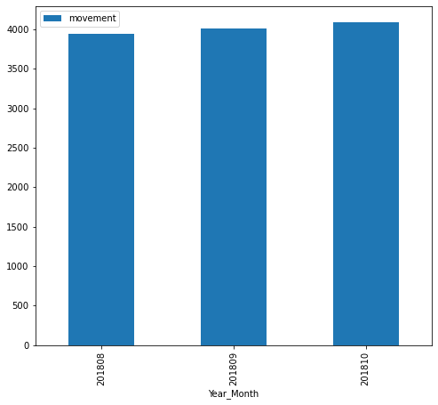

```python
monthly_movement = data[['Year_Month', 'movement']].groupby('Year_Month').count()
monthly_movement.plot(kind = 'bar', figsize = (8,7))
```

```python
monthly_movement.describe()
```

|  | movement |
| --- | --- |
| count | 3.000000 |
| mean | 4014.333333 |
| std | 72.009259 |
| min | 3943.000000 |
| 25% | 3978.000000 |
| 50% | 4013.000000 |
| 75% | 4050.000000 |
| max | 4087.000000 |

```python
data. head(3)
```

|  | status | card_present_flag | long_lat | txn_description | balance | date | gender | age | merchant_suburb | merchant_state | extraction | amount | merchant_long_lat | movement | Year_Month |
| --- | --- | --- | --- | --- | --- | --- | --- | --- | --- | --- | --- | --- | --- | --- | --- |
| 0 | authorized | 1.0 | 153.41 -27.95 | POS | 35.39 | 2018-08-01 | F | 26 | Ashmore | QLD | 2018-08-01T01:01:15.000+0000 | 16.25 | 153.38 -27.99 | debit | 201808 |
| 1 | authorized | 0.0 | 153.41 -27.95 | SALES-POS | 21.20 | 2018-08-01 | F | 26 | Sydney | NSW | 2018-08-01T01:13:45.000+0000 | 14.19 | 151.21 -33.87 | debit | 201808 |
| 2 | authorized | 1.0 | 151.23 -33.94 | POS | 5.71 | 2018-08-01 | M | 38 | Sydney | NSW | 2018-08-01T01:26:15.000+0000 | 6.42 | 151.21 -33.87 | debit | 201808 |

```python
data.to_csv('C:/Users/Guoli/Documents/Data Science Material/Projects/ANZ/datasetaftertask1.csv')
```